# **DATA MINING - Projet Botanic**

- **Etudiants** : Faiçal SBAI & Alain BONDZA
- **Année de réalisation** : 2023
- **Sujet** :
- **Attrition des clients** : Identifier les clients qui sont attritionnistes en 2017 versus ceux qui sont non attritionnistes
- **Histoire et Contexte** :
- Botanic® est une chaîne de magasins fondée en France en 1995. L'enseigne propose une sélection de plantes, d'outils de jardinage, de produits bio pour le jardin et la maison, ainsi que des conseils de jardinage écologique. Elle se positionne sur la thématique du respect de l'environnement et la promotion du développement durable.
- Au travers d’un réseau de 70 magasins en France, Botanic® est le troisième groupe sur le marché de la jardinerie en France après InVivo et Truffaut.
- Comme toute entreprise, Botanic peut être confrontée à un défis de fidélisation de sa clientèle. L'attrition de ses clients peut être due à plusieurs facteurs, tels que :
  - Une Concurrence accrue à travers l'émergence de nouvelles enseignes, ou de la présence d'autres concurrents dans le secteur du jardinage et des produits bio.
  - Une évolution des préférences de ses consommateurs avec le temps, ce qui doit conduire Botanic® à s'adapter pour répondre aux nouvelles demandes du marché. Si les clients trouvent des alternatives plus attractives, ou si les produits de Botanic® ne correspondent plus à leurs besoins, cela peut entraîner une attrition des clients.
  - Un service à la clientèle médiocre, qui occasionne des problèmes récurrents, et peut entraîner une baisse de la fidélité des clients.
  - Les changements économiques dû aux fluctuations économiques, telles que les récessions ou les périodes de ralentissement économique, peuvent affecter les dépenses des consommateurs et entraîner une réduction de sa clientèle.
- **Botanic® en bref (2016-2017)** :
- **ACTIVITÉ** : jardinerie, animalerie, décoration, marché bio, bien-être.
- **CRÉATION** : 1977 (Les Serres du Salève) et 1995 (marque Botanic)
- **IMPLANTATION** : Archamps (siège social)
- **CHIFFRE D’AFFAIRES** : 364M€ (2016-2017)
- **EFFECTIFS** : 2200 salariés
- **MAGASINS (France)** : 70
- **RÉPARTITION DU CAPITAL** : les familles « opérationnelles » Blanchet et Bouchet viennent d’augmenter leur participation, les familles Verdonnet ayant vendu une grande partie de leurs parts. Les montants ne sont pas communiqués.
- **Demande de l'enseigne Botanic®** : L’ambition de l'enseigne Botanic® est de devenir la jardinerie naturelle préférée des français en conciliant jardin et nature, croissance et responsabilité sociétale de l’entreprise. Pour cette raison, l'enseigne Botanic® souhaite :
  - Identifier les clients attritionnistes en 2017.
  - Disposer d'un modèle prédictif de l'attrition.
  - Obtenir des recommandations marketing de rétention des clients encore actifs mais à risque d'attrition en 2017.
- **Objectif** :
  - Expliquer (et mesurer) l'influence de facteurs sur un départ des clients à la concurrence (l'attrition des clients)
    - Prédire le risque de départ à la concurrence d'un client.
  - Prédire l'événement : Prendre des décisions pour agir sur certains facteurs :
    - retenir les clients,
    - optimiser les offres commerciales,
    - mieux cibler une campagne marketing,
    - diminuer le risque de départ à la concurrence,
    - personnaliser les actions commerciales, etc.
- **Source des données** :
  - Bases de données de l’enseigne Botanic des années 2016 et 2017.
- **Périmètre de l’étude** :
  - Le périmètre de l’étude est limitée à plusieurs régions en France pour les clients non-VIP uniquement.
  - Focus sur les clients ayant fait au moins 2 achats
- **Modélisation** : Supervisée. **Modèle** : Régression Logistique
  - La régression logistique est le modèle qui sera utilisé dans le cadre de ce projet.

[figure not shown]

# **1- Initialisation de l'environnement**

```python
%%javascript
IPython.OutputArea.auto_scroll_threshold = 9999
```

```python
#! pip install pretty-jupyter
import numpy as np                      # Pour faire des tableaux
import pandas as pd                     # Pour manipuler les dataframes
import matplotlib.pyplot as plt         # Pour les graphiques
import seaborn as sns                   # Pour visualisation des données
import stats_desc as st                 # Pour les statistiques (besoin que le fichier "stats_desc.py" soit dans le même dossier que ce notebook).
import datetime as dt

import gc ## Garbadge collector pour liberer la mémoire
pd.set_option('display.max_row', 111)
pd.set_option('display.max_column', 111)
```

# **2- Lecture des fichiers en entrée**

```python
## Fonction de conversion de CSV à Parquet
def CSVtoParquet(CSVPath, ParquetPath):
    df = pd.read_csv(CSVPath, sep = '|',dtype = {'IDCLIENT':'string','IDTICKET':'string','MAGASIN':'string','CODESOCIETE':'string','CIVILITE':'string','MAG_CODE':'string','IDARTICLE':'string','CODEARTICLE':'string', 'CODEINSEE': 'string', 'IDARTICLE': 'string', 'CODEARTICLE': 'string', 'CODEFAMILLE': 'string', 'CODESOUSFAMILLE': 'string', 'TIC_TOTALTTC':'float', 'QUANTITE':'float', 'MONTANTREMISE':'float', 'TOTAL':'float', 'MARGESORTIE':'float'},decimal=',')
    df.to_parquet(ParquetPath)
```

```python
# Conversion de la table entete ticket
CSVfilepath = 'import/ENTETES_TICKET_V4.CSV'
Parquetfilepath = 'import/ENTETES_TICKET_V4.parquet'
CSVtoParquet(CSVfilepath, Parquetfilepath)

# Conversion de la table ligne ticket
CSVfilepath = 'import/LIGNES_TICKET_V4.CSV'
Parquetfilepath = 'import/LIGNES_TICKET_V4.parquet'
CSVtoParquet(CSVfilepath, Parquetfilepath)
```

```python
# Lecture de la table client

Parquetfilepath = 'import/ENTETES_TICKET_V4.parquet'
df =pd.read_parquet(Parquetfilepath)
```

```python
gc.collect(generation=2)
```

```
1201
```

```python
df.dtypes
```

```
IDTICKET         string
TIC_DATE         object
MAG_CODE         string
IDCLIENT         string
TIC_TOTALTTC    float64
dtype: object
```

# **3- Vérification de la structure des tables**

(colonnes, lignes) – statistiques descriptives et 1ères observations

## **I-1 Analyse de Forme :**

```python
df.head()
```

|  | IDTICKET | TIC_DATE | MAG_CODE | IDCLIENT | TIC_TOTALTTC |
| --- | --- | --- | --- | --- | --- |
| 0 | 50100150510 | 2016-01-02 11:01:33 | ALB | 2995104 | 12.90 |
| 1 | 50100150511 | 2016-01-02 11:02:10 | ALB | 1411117 | 131.06 |
| 2 | 50100150515 | 2016-01-02 12:03:27 | ALB | 222592 | 34.69 |
| 3 | 50100150517 | 2016-01-02 14:23:21 | ALB | 2979958 | 97.58 |
| 4 | 50100150518 | 2016-01-02 14:26:53 | ALB | 2858676 | 4.70 |

```python
## La table entete ticket contient 5 colonnes et 6714173 lignes
df.shape
```

```
(6714173, 5)
```

```python
# LEs types de collones
df.dtypes
```

```
IDTICKET         string
TIC_DATE         object
MAG_CODE         string
IDCLIENT         string
TIC_TOTALTTC    float64
dtype: object
```

```python
# Il n'y a pas de valeurs manquantes dans cette table
(df.isna().sum()/df.shape[0]).sort_values(ascending=True)
```

```
IDTICKET        0.0
TIC_DATE        0.0
MAG_CODE        0.0
IDCLIENT        0.0
TIC_TOTALTTC    0.0
dtype: float64
```

## **I-1 Analyse de Fond :**

```
TIC_DATE-- ['2016' '2017']
```

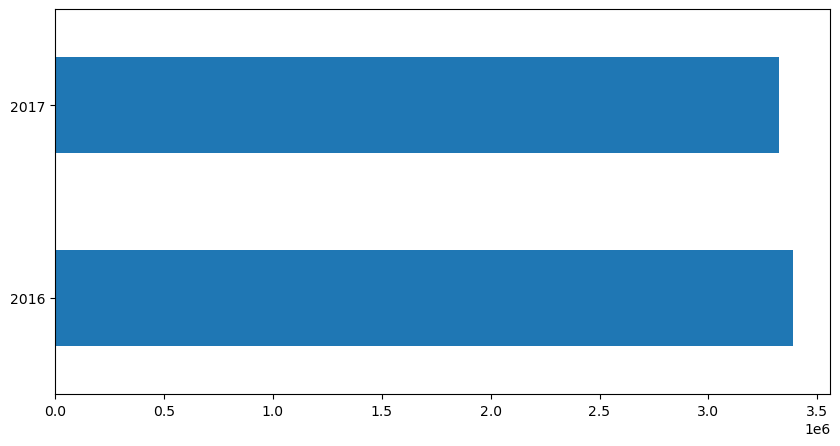

```python
# repartition des dates d'achat par année
plt.figure(figsize=(10,5))
pddateadh = pd.to_datetime(df['TIC_DATE']).dt.strftime('%Y')
print(f'{"TIC_DATE" :-<10} {pddateadh.unique()}')
pddateadh.value_counts().plot.barh()
```

```python
import pandas as pd
# Fonction qui remplace les valeurs NaN par zéro
def replace_nan_with_zero(df):
    # Remplacer NaN par 0 dans le dataframe
    df.fillna(value=0, inplace=True)
```

```python
#Appel de la fonction replace_nan_with_zero
replace_nan_with_zero(df)
```

```python
var_quanti = ['TIC_TOTALTTC']
st.get_stats_quanti(df[var_quanti])
```

|  | dtype | min | max | mean | std | median | taux_na | taux_var |
| --- | --- | --- | --- | --- | --- | --- | --- | --- |
| TIC_TOTALTTC | float64 | -4404.0 | 15355.25 | 58.15421 | 86.719956 | 37.6 | 0.0 | 1.491207 |

```python
import seaborn as sns
# Fonction d'affichage du graphique pour afficher les valeurs extrêmes
def plot_moustache_sans_outliers(df, col_name):
    # Supprimer les valeurs extrêmes
    df = df[(df[col_name] >= df[col_name].quantile(0.01)) & (df[col_name] <= df[col_name].quantile(0.99))]

    # Tracer le boxplot
    sns.boxplot(x=df[col_name])

    # Ajouter un titre
    plt.title('Courbe de moustache sans les valeurs extrêmes de ' + col_name)

    # Afficher le graphique
    plt.show()
```

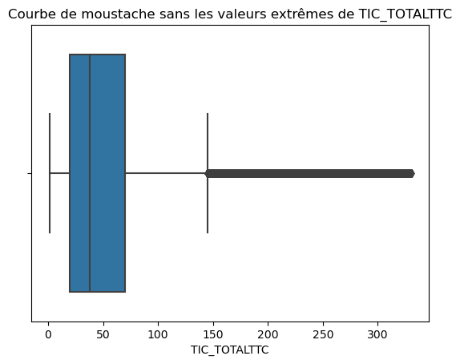

```python
# Appel de la fonction
data = df["TIC_TOTALTTC"]
plot_moustache_sans_outliers(df,"TIC_TOTALTTC" )
```

```python
# Fonction qui elimine les outliers
def eliminer_outliers(df, col_name, q1=0.01, q2=0.99):
    # Calculer les quantiles
    q_low = df[col_name].quantile(q1)
    q_high = df[col_name].quantile(q2)

    # Supprimer les valeurs en dehors des quantiles
    df = df[(df[col_name] >= q_low) & (df[col_name] <= q_high)]

    # Retourner le dataframe modifié
    return df
```

```python
# Appel de la fonction
df = eliminer_outliers(df, 'TIC_TOTALTTC', q1=0.01, q2=0.99)
```

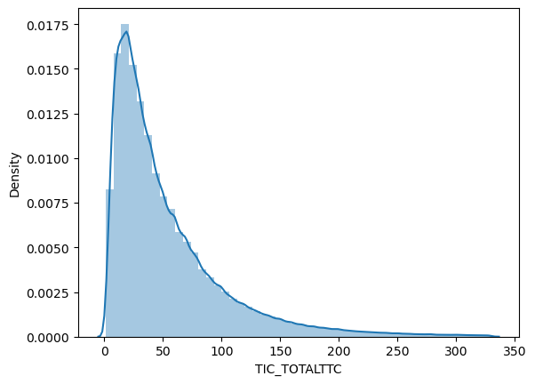

```python
plt.figure()
sns.distplot(df['TIC_TOTALTTC'])
```

```python
# Filtre des données sur l'année 2016
from datetime import datetime
annee_filtre = 2016
df['TIC_DATE'] = pd.to_datetime(df['TIC_DATE'])
filtered_data = df[df['TIC_DATE'].dt.year == annee_filtre]
```

```python
filtered_data.head()
```

|  | IDTICKET | TIC_DATE | MAG_CODE | IDCLIENT | TIC_TOTALTTC |
| --- | --- | --- | --- | --- | --- |
| 0 | 50100150510 | 2016-01-02 11:01:33 | ALB | 2995104 | 12.90 |
| 1 | 50100150511 | 2016-01-02 11:02:10 | ALB | 1411117 | 131.06 |
| 2 | 50100150515 | 2016-01-02 12:03:27 | ALB | 222592 | 34.69 |
| 3 | 50100150517 | 2016-01-02 14:23:21 | ALB | 2979958 | 97.58 |
| 4 | 50100150518 | 2016-01-02 14:26:53 | ALB | 2858676 | 4.70 |

```python
# Fonction qui calcule les scores RFM d'un client : Récence, Fréquence et valeur monétaire

def calculer_RFM_actif(df, date_col, customer_id_col, transaction_value_col):
    # Calculer la date maximale dans le dataframe
    max_date = df[date_col].max() #datetime.strptime(df[date_col].max(), '%Y-%m-%d %H:%M:%S')

    # Calculer la récence pour chaque client
    #recency_df = df.groupby(customer_id_col)[date_col].apply(lambda x: (max_date - datetime.strptime(x.max(), '%Y-%m-%d  %H:%M:%S')).days)
    recency_df = df.groupby(customer_id_col)[date_col].apply(lambda x: (max_date - x.max()).days)
    recency_df.name = 'recency'

    # Calculer la fréquence pour chaque client
    frequency_df = df.groupby(customer_id_col)[transaction_value_col].count()
    frequency_df.name = 'frequency'

    # Calculer la valeur monétaire pour chaque client
    monetary_value_df = df.groupby(customer_id_col)[transaction_value_col].sum()
    monetary_value_df.name = 'monetary_value'

    # Joindre les résultats en un seul dataframe
    rfm_df = pd.concat([recency_df, frequency_df, monetary_value_df], axis=1)

    # Calculer les scores RFM
    rfm_df['r_score'] = pd.qcut(rfm_df['recency'], q=4, labels=False) + 1
    rfm_df['f_score'] = pd.qcut(rfm_df['frequency'], q=4, labels=False) + 1
    rfm_df['m_score'] = pd.qcut(rfm_df['monetary_value'], q=4, labels=False) + 1

    # Calculer le score RFM
    #rfm_df['rfm_score'] = rfm_df['r_score'].astype(str) + rfm_df['f_score'].astype(str) + rfm_df['m_score'].astype(str)

    # Identifier si le client est actif ou non
    # si les scores de la recence et la frequence et le montant sont superieur à 2 alors le client est actif sinon le client est inactif
    #rfm_df['TypeClient'] = rfm_df.apply(lambda row: 'actif' if int(row['r_score']) > 2 and int(row['f_score']) > 2 and int(row['m_score']) > 2 else 'inactif', axis=1)

    return rfm_df
```

```python
# Appel de la fonction
rfm_df = calculer_RFM_actif(filtered_data, 'TIC_DATE', 'IDCLIENT', 'TIC_TOTALTTC')
```

```python
rfm_df.head()
```

| IDCLIENT | recency | frequency | monetary_value | r_score | f_score | m_score |
| --- | --- | --- | --- | --- | --- | --- |
| 10000 | 41 | 14 | 510.14 | 2 | 4 | 4 |
| 100002 | 61 | 8 | 227.52 | 2 | 4 | 3 |
| 100008 | 190 | 3 | 128.28 | 4 | 2 | 2 |
| 100010 | 22 | 7 | 239.45 | 1 | 3 | 3 |
| 100012 | 24 | 8 | 267.87 | 2 | 4 | 3 |

```python
df.columns
df_client_final = pd.merge(df, rfm_df, on='IDCLIENT')
```

```python
df_client_final.head()
```

|  | IDTICKET | TIC_DATE | MAG_CODE | IDCLIENT | TIC_TOTALTTC | recency | frequency | monetary_value | r_score | f_score | m_score |
| --- | --- | --- | --- | --- | --- | --- | --- | --- | --- | --- | --- |
| 0 | 50100150510 | 2016-01-02 11:01:33 | ALB | 2995104 | 12.90 | 4 | 20 | 278.99 | 1 | 4 | 3 |
| 1 | 50600475249 | 2016-02-05 10:17:06 | ALB | 2995104 | 25.45 | 4 | 20 | 278.99 | 1 | 4 | 3 |
| 2 | 50600478883 | 2016-02-22 11:28:28 | ALB | 2995104 | 13.50 | 4 | 20 | 278.99 | 1 | 4 | 3 |
| 3 | 50600480760 | 2016-03-01 11:14:00 | ALB | 2995104 | 10.95 | 4 | 20 | 278.99 | 1 | 4 | 3 |
| 4 | 50600485678 | 2016-03-24 09:14:54 | ALB | 2995104 | 9.25 | 4 | 20 | 278.99 | 1 | 4 | 3 |

```python
# Sauvegarde des données sous format parquet
Parquetfilepath = 'import/entete_nettoye_finale.parquet'
df_client_final.to_parquet(Parquetfilepath)
```